# An Intro Into Doing Data Science Using Python

# Through an Analysis of the Effects of Air Pollution on Health in California

Jack Anderson, Josh Lu, Thomas Johnson, Tyler Kempton

# What is Air Pollution?

When chemical, physical, or biological agents are relased into the enviorment, that enviorment becomes polluted over time. Air pollution in particular refers to the particulates of pollution that are present in the air.

The primariry causes of air pollution are vehicle emissions, the burning of fuel oils and natural gas, and as a by-product of manufacturing and power generation.

# Why Care about Air Pollution?

Air pollution is one of the world's leading health risk factors, with an estimated 6.7 million premature deaths ocurring annually due to its prevelance. The World Health Organization and the Center for Disease Control both recognize the prevelance of pollutants in the air as a [major threat to public health](https://www.who.int/health-topics/air-pollution#tab=tab_1).

Due to the fact that air pollution is mostly caused by human industrialization, different areas experience vastly different levels of pollution, with urban areas typically being far worse off than rural areas.

More than [99% of the world's population](https://www.who.int/news/item/04-04-2022-billions-of-people-still-breathe-unhealthy-air-new-who-data) lives in an area exceeding WHO air quality limits. With a greater percent of the world population living in densly populated urban areas each year, this means that more and more people will be concentrated in areas where air pollution is worst.

Air pollution is believed to [disproportionatally affect](https://www.lung.org/clean-air/outdoors/who-is-at-risk/disparities) certain groups of people. Notably, immunocompromised and working class individuals are those that are generally thought to be more often affected negatively by high exposure to contaminated air in their area.

# What is our Goal?

We want to use our knowledge to analyze the extent to which air quality, measured as AQI, affects the health of humans. We want to specifically evaluate lung diseases that are commonly associated with poor air quality, such as asthma, chronic obstructive pulmonary disease (COPD), and lung cancer. Ideally our goal is to establish some kind of correlation between air quality and these diseases.

# What Data are we using?

We will be exlusively using data collected on the various counties of California over the 2015-2019 time interval. We selected California for this demonstration as there are many readily available datasets on AQI, income, and health conditions present. Through a basic analysis of our data, we saw that California also has a wide range of counties with very good AQIs and very poor AQIs. The 2015-2019 interval is ideal for our investigation because it provides us a range of years that are relatively recent, meaning the results of our analysis will still be relevant to the real world. Evaluating data for a range of years will also protect us from analyzing only a particular year that could be an outlier (a year that had a high number of forest fires, for example). Because our analysis is not focused on differences across time, the shorter time frame of 5 years is acceptable.

# Importing Libraries

Our work requires libraries commonly associated with data science such as numpy and pandas. We use matplotlib for data visualization, beautifulsoup for web scraping, and sklearn and smf for our hypothesis testing, as well as a few other libraries for various purposes.

```python
#Downloading Necessary Libraries
%pip install lxml
%pip install html5lib
```

```python
#Final Tutorial
#Importing Necessary Libraries
import sqlite3
import numpy as np
import pandas as pd
import math
import matplotlib.pyplot as plt
import requests
import statsmodels.api as sm
import statsmodels.formula.api as smf
from sklearn.linear_model import LinearRegression
import seaborn
import html5lib
import re
import inspect
from bs4 import BeautifulSoup
```

# Data Collection

We compiled data from a variety of sources listed below:

```python
#The urls for each year from 2014-2020 of state asthma data
url = "https://www.cdc.gov/asthma/most_recent_data_states.htm"
url2 = "https://www.cdc.gov/asthma/archivedata/2019/2019_archived_states_territory.html"
url3 = "https://www.cdc.gov/asthma/archivedata/2018/2018_archived_states_territory.html"
url4 = "https://www.cdc.gov/asthma/archivedata/2017/2017_archived_states_territory.html"
url5 = "https://www.cdc.gov/asthma/archivedata/2016/2016-archived-data-states.html"
url6 = "https://www.cdc.gov/asthma/archivedata/2015/2015_data_states.html"
url7 = "https://www.cdc.gov/asthma/archivedata/2014/2014_data_states.html"

# Header tells the website who the user trying to access the data is
# Stops the website from figuring out that we are trying to scrape data from it
headers = {
    'User-Agent': 'Mozilla/5.0 (Windows NT 10.0; Win64; x64) AppleWebKit/537.36 (KHTML, like Gecko) Chrome/109.0.0.0 Safari/537.36',
    'From': 'jackand356@gmail.com'
}

# Grabs each of the pages from the urls, using requests
page = requests.get(url, headers=headers)
page2 = requests.get(url2, headers=headers)
page3 = requests.get(url3, headers=headers)
page4 = requests.get(url4, headers=headers)
page5 = requests.get(url5, headers=headers)
page6 = requests.get(url6, headers=headers)
page7 = requests.get(url7, headers=headers)
```

```python
# Creates a soup out of the text of each page
soup = BeautifulSoup(page.text)
soup2 = BeautifulSoup(page2.text)
soup3 = BeautifulSoup(page3.text)
soup4 = BeautifulSoup(page4.text)
soup5 = BeautifulSoup(page5.text)
soup6 = BeautifulSoup(page6.text)
soup7 = BeautifulSoup(page7.text)

# Using beautiful soup, it allows us to find a specific table out of each of pages
# To grab any table you want from a website, you can refer to this https://www.scraperapi.com/blog/python-loop-through-html-table/
# Getting just the data from our specified table
htmltable = soup.find('table', { 'class' : 'table table-striped table-bordered nein-scroll' })
htmltable2 = soup2.find('table', { 'class' : 'table table-striped table-bordered nein-scroll' })
htmltable3 = soup3.find('table', { 'class' : 'table table-striped table-bordered nein-scroll' })
htmltable4 = soup4.find('table', { 'class' : 'col-md-12 table-striped nein-scroll table-bordered' })
htmltable5 = soup5.find('table', { 'class' : 'table-striped nein-scroll table-bordered col-md-12' })
htmltable6 = soup6.find('table', { 'class' : 'table table-bordered table-striped' })
htmltable7 = soup7.find('table', { 'class' : 'table table-bordered table-striped' })

# Turns the htmltables into dataframes, which are 2d arrays with labels, allowing us to easily search for and modify our data
frame = pd.read_html(str(htmltable))[0]
frame2 = pd.read_html(str(htmltable2))[0]
frame3 = pd.read_html(str(htmltable3))[0]
frame4 = pd.read_html(str(htmltable4))[0]
frame5 = pd.read_html(str(htmltable5))[0]
frame6 = pd.read_html(str(htmltable6))[0]
frame7 = pd.read_html(str(htmltable7))[0]


# Trims off the standard deviation from the Percent W/ Current Asthma and then converts the percentage string into a float
for index in range(frame['Percent With Current Asthma (SE)'].size):
    curr_str = re.search(r'\d+\.\d+', frame['Percent With Current Asthma (SE)'][index]).group()
    curr = float(curr_str)
    frame.at[index, 'Percent With Current Asthma (SE)'] = curr

for index in range(frame2['Percent with Current Asthma (SE)'].size):
    #Index 30 in this df has a value of --, which won't match the regex and shouldn't be used
    if index != 30:
        curr_str = re.search(r'\d+\.\d+', frame2['Percent with Current Asthma (SE)'][index]).group()
        curr = float(curr_str)
        frame2.at[index, 'Percent with Current Asthma (SE)'] = curr

for index in range(frame3['Percent with Current Asthma (SE)'].size):
    curr_str = re.search(r'\d+\.\d+', frame3['Percent with Current Asthma (SE)'][index]).group()
    curr = float(curr_str)
    frame3.at[index, 'Percent with Current Asthma (SE)'] = curr

#Renames all of the columns of the dataframes to match one another
frame = frame.set_axis(['State or Territory', 'Number with Current Asthma', 'Percent with Current Asthma'], axis=1)
frame['Year'] = 2020
#Sets that outlier variable talked about earlier to NaN
frame2.at[30, 'Percent with Current Asthma (SE)'] = np.NaN
frame2 = frame2.set_axis(['State or Territory', 'Number with Current Asthma', 'Percent with Current Asthma'], axis=1)
frame2['Year'] = 2019
frame3 = frame3.set_axis(['State or Territory', 'Number with Current Asthma', 'Percent with Current Asthma'], axis=1)
frame3['Year'] = 2018
frame4 = frame4.set_axis(['State or Territory', 'Number with Current Asthma', 'Percent with Current Asthma'], axis=1)
frame4['Year'] = 2017
frame5 = frame5.set_axis(['State or Territory', 'Number with Current Asthma', 'Percent with Current Asthma'], axis=1)
frame5['Year'] = 2016
frame6 = frame6.set_axis(['State or Territory', 'Number with Current Asthma', 'Percent with Current Asthma'], axis=1)
frame6['Year'] = 2015
frame7 = frame7.set_axis(['State or Territory', 'Number with Current Asthma', 'Percent with Current Asthma'], axis=1)
frame7['Year'] = 2014

#Combines all of the dataframes into one
frames = [frame, frame2, frame3, frame4, frame5, frame6, frame7]
combined_asthma = pd.concat(frames)
frame2.head()
```

|  | State or Territory | Number with Current Asthma | Percent with Current Asthma | Year |
| --- | --- | --- | --- | --- |
| 0 | Alabama | 360965 | 9.5 | 2019 |
| 1 | Alaska | 54239 | 9.9 | 2019 |
| 2 | Arizona | 544394 | 9.7 | 2019 |
| 3 | Arkansas | 215095 | 9.3 | 2019 |
| 4 | California | 2405797 | 7.8 | 2019 |

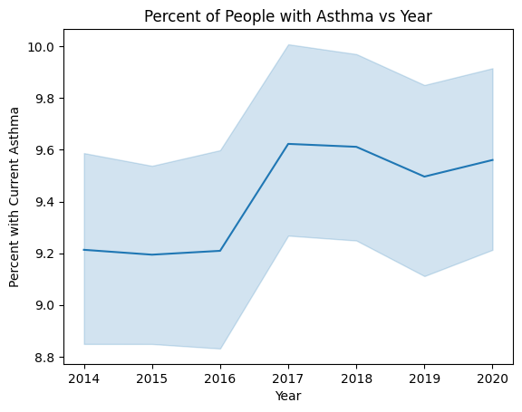

```python
#Graphs the aggregate asthma rate per year as a line graph from 2014-2020
#The light blue shaded area is the 95% confidence interval for each year
#Because the data was combined using concat on multiple dataframes, there are many duplicate indexed rows,
#as concat does not change any indexes, so to graph or grab rows by index we have to reindex the dataframe

combined_asthma = combined_asthma.reset_index()
seaborn.lineplot(data=combined_asthma, y="Percent with Current Asthma", x="Year")
plt.title("Percent of People with Asthma vs Year")
#Asthma has increased by almost half a percent of the population in the past 7 years
```

# Cleaning Air Quality Index (AQI) Data

This data was already relatively clean and tidy. All we did here was remove the rows that corresponded to counties not in the state of California.

```python
#Questions, given air quality by year, and asthma hospitalizations by year.
#Given a four year interval, the total number of hospitalizations versus the average air quality of those four years, for each county
#Statistical analysis on that
#aqi_df = df = pd.read_csv('annual_aqi_by_county_2015-2019.csv')
aqi_df = pd.read_csv('https://raw.githubusercontent.com/ThomasJohnson35/CMSC320-datasets/main/annual_aqi_by_county_2015-2019.csv')

#Drop all non California rows, reindex
california_aqi_df = aqi_df[aqi_df['State'] == 'California']
california_aqi_df.reset_index(drop=True,inplace=True)
california_aqi_df.head()
```

|  | State | County | Year | Days with AQI | Good Days | Moderate Days | Unhealthy for Sensitive Groups Days | Unhealthy Days | Very Unhealthy Days | Hazardous Days | Max AQI | 90th Percentile AQI | Median AQI | Days CO | Days NO2 | Days Ozone | Days PM2.5 | Days PM10 |
| --- | --- | --- | --- | --- | --- | --- | --- | --- | --- | --- | --- | --- | --- | --- | --- | --- | --- | --- |
| 0 | California | Alameda | 2015 | 365 | 214 | 139 | 12 | 0 | 0 | 0 | 147 | 76 | 46 | 0 | 15 | 180 | 170 | 0 |
| 1 | California | Alpine | 2015 | 31 | 1 | 14 | 13 | 3 | 0 | 0 | 170 | 149 | 102 | 0 | 0 | 0 | 31 | 0 |
| 2 | California | Amador | 2015 | 364 | 283 | 73 | 8 | 0 | 0 | 0 | 140 | 67 | 41 | 0 | 0 | 364 | 0 | 0 |
| 3 | California | Butte | 2015 | 365 | 170 | 182 | 12 | 1 | 0 | 0 | 152 | 84 | 52 | 0 | 0 | 237 | 127 | 1 |
| 4 | California | Calaveras | 2015 | 365 | 245 | 98 | 18 | 2 | 1 | 1 | 320 | 90 | 45 | 0 | 0 | 274 | 91 | 0 |

# Cleaning Asthma Hospitalizations Data

In this step, after importing the dataset, we kept only the rows that included metrics for the total population since our analysis did not cover certain demographic factors. We kept and renamed only the relevant columns, since there were other more in-depth measurements of air quality that we did not need.

```python
#Creating a pandas dataframe from a CSV file (californian asthma hospitalizations by county from data.gov)


asthma_df = pd.read_csv(
    #"asthma_by_county.csv"
    'https://raw.githubusercontent.com/ThomasJohnson35/CMSC320-datasets/main/asthma-hospitalization-rates-by-county-2015_2019.csv'
    ,encoding='cp1252',thousands=',')

# Combine Asthma dataframe -- want only rows with same county/year combo, and one to one with total population and all ages
filtered_asthma_df = asthma_df[asthma_df['STRATA'] == 'Total population']

#Drop unnecessary collumns
filtered_asthma_df = filtered_asthma_df[['COUNTY', 'YEAR', 'NUMBER OF HOSPITALIZATIONS', 'AGE-ADJUSTED HOSPITALIZATION RATE']]

#For now using total populations, re-indexing
filtered_asthma_df.reset_index(drop=True,inplace=True)


filtered_asthma_df = filtered_asthma_df.rename(columns={'COUNTY': 'County',
                          'YEAR': 'Year',
                          'STRATA': 'Strata',
                          'STRATA NAME': 'Strata_name',
                          'AGE GROUP': 'Age_group',
                          'NUMBER OF HOSPITALIZATIONS': 'Num_hosp',
                          'AGE-ADJUSTED HOSPITALIZATION RATE': 'Adj_hosp_rate',
                          'COMMENT': 'Comment'})
```

# Merging AQI and Asthma Data

After importing and doing some intial cleaning of our main datasets, we performed an inner join of the data on the year and county columns. This effectively created one dataset with the necessary columns from each source for every county and year combination. We used an inner join because we wanted entries that only had year and county combinations in both datasets.

```python
merged_df = pd.merge(filtered_asthma_df,california_aqi_df, on=['Year','County'])
merged_df.head()
```

|  | County | Year | Num_hosp | Adj_hosp_rate | State | Days with AQI | Good Days | Moderate Days | Unhealthy for Sensitive Groups Days | Unhealthy Days | Very Unhealthy Days | Hazardous Days | Max AQI | 90th Percentile AQI | Median AQI | Days CO | Days NO2 | Days Ozone | Days PM2.5 | Days PM10 |
| --- | --- | --- | --- | --- | --- | --- | --- | --- | --- | --- | --- | --- | --- | --- | --- | --- | --- | --- | --- | --- |
| 0 | Alameda | 2015 | 1435.0 | 9.3 | California | 365 | 214 | 139 | 12 | 0 | 0 | 0 | 147 | 76 | 46 | 0 | 15 | 180 | 170 | 0 |
| 1 | Alpine | 2015 | 0.0 | 0.0 | California | 31 | 1 | 14 | 13 | 3 | 0 | 0 | 170 | 149 | 102 | 0 | 0 | 0 | 31 | 0 |
| 2 | Amador | 2015 | 28.0 | 7.5 | California | 364 | 283 | 73 | 8 | 0 | 0 | 0 | 140 | 67 | 41 | 0 | 0 | 364 | 0 | 0 |
| 3 | Butte | 2015 | 143.0 | 6.7 | California | 365 | 170 | 182 | 12 | 1 | 0 | 0 | 152 | 84 | 52 | 0 | 0 | 237 | 127 | 1 |
| 4 | Calaveras | 2015 | 32.0 | 6.5 | California | 365 | 245 | 98 | 18 | 2 | 1 | 1 | 320 | 90 | 45 | 0 | 0 | 274 | 91 | 0 |

# Cleaning Population Census Data

After processing our asthma hospitalizations data, we realized that the dataset lacked a total population number for each county. This feature is essential because our asthma hospitalizations data was in the form of number of hospitalizations, so we had no way of knowing if a number was significant or not in relation to the county's population. Luckily, we found population data for our selected timeframe from the Census Bureau.

# Data cleaning steps we took:

- Limiting the counties to only counties in California.
- The dataset included 160+ columns, but we only needed the ones marking population estimates for each county. So we selected only the population estimates that were relevant.
- Many rows were missing data. We dropped those.
- We renamed columns to match our previous style.
- We performed a melt on the dataset that took the 5 columns holding population estimates for each of the 5 years, and created additional rows for each county and condensed the multiple population estimate columns into one population estimate column while creating additional rows for each county and year combination.
- We passed every entry's 'County' columns through regex to remove unnecessary formatting.

```python
# format popualtion df by removing columns, renaming, melting
pop = pd.read_csv(
    #'co-est2019-alldata.csv'
    'https://raw.githubusercontent.com/ThomasJohnson35/CMSC320-datasets/main/co-est2019-alldata.csv'
    ,encoding='cp1252')

display(pop)

# Grabs only rows with California as their state
pop = pop[pop['STNAME'] == 'California']

# Obtains the columns we're interested in
pop = pop[['STNAME', 'CTYNAME', 'POPESTIMATE2015',
        'POPESTIMATE2016', 'POPESTIMATE2017', 'POPESTIMATE2018', 'POPESTIMATE2019' ]]

# Drops rowwith missing population data
pop.dropna()

# Rename to fit our formatting
pop = pop.rename(columns={'STNAME': 'State', 'CTYNAME': 'County'})


pop = pd.melt(pop, id_vars=['State', 'County'], var_name='Year', value_name='Population')
pop['Year'] = pop['Year'].str.extract(r'(\d+)', expand=False).astype(int)
pop['County'] = pop['County'].str.replace(r'\ County$', '')

#pop['Year'] = pop['Year'].str.extract(r'(\d+)', expand=False).astype(int)
#pop['County'] = pop['County'].str.replace(r'\ County$', '')
pop.head()
```

|  | SUMLEV | REGION | DIVISION | STATE | COUNTY | STNAME | CTYNAME | CENSUS2010POP | ESTIMATESBASE2010 | POPESTIMATE2010 | ... | RDOMESTICMIG2019 | RNETMIG2011 | RNETMIG2012 | RNETMIG2013 | RNETMIG2014 | RNETMIG2015 | RNETMIG2016 | RNETMIG2017 | RNETMIG2018 | RNETMIG2019 |
| --- | --- | --- | --- | --- | --- | --- | --- | --- | --- | --- | --- | --- | --- | --- | --- | --- | --- | --- | --- | --- | --- |
| 0 | 40 | 3 | 6 | 1 | 0 | Alabama | Alabama | 4779736 | 4780125 | 4785437 | ... | 1.917501 | 0.578434 | 1.186314 | 1.522549 | 0.563489 | 0.626357 | 0.745172 | 1.090366 | 1.773786 | 2.483744 |
| 1 | 50 | 3 | 6 | 1 | 1 | Alabama | Autauga County | 54571 | 54597 | 54773 | ... | 4.847310 | 6.018182 | -6.226119 | -3.902226 | 1.970443 | -1.712875 | 4.777171 | 0.849656 | 0.540916 | 4.560062 |
| 2 | 50 | 3 | 6 | 1 | 3 | Alabama | Baldwin County | 182265 | 182265 | 183112 | ... | 24.017829 | 16.641870 | 17.488579 | 22.751474 | 20.184334 | 17.725964 | 21.279291 | 22.398256 | 24.727215 | 24.380567 |
| 3 | 50 | 3 | 6 | 1 | 5 | Alabama | Barbour County | 27457 | 27455 | 27327 | ... | -5.690302 | 0.292676 | -6.897817 | -8.132185 | -5.140431 | -15.724575 | -18.238016 | -24.998528 | -8.754922 | -5.165664 |
| 4 | 50 | 3 | 6 | 1 | 7 | Alabama | Bibb County | 22915 | 22915 | 22870 | ... | 1.385134 | -4.998356 | -3.787545 | -5.797999 | 1.331144 | 1.329817 | -0.708717 | -3.234669 | -6.857092 | 1.831952 |
| ... | ... | ... | ... | ... | ... | ... | ... | ... | ... | ... | ... | ... | ... | ... | ... | ... | ... | ... | ... | ... | ... |
| 3188 | 50 | 4 | 8 | 56 | 37 | Wyoming | Sweetwater County | 43806 | 43806 | 43574 | ... | -17.605427 | 0.502513 | 15.035735 | -4.614071 | -13.140225 | -13.762031 | -18.484164 | -23.515727 | -18.743773 | -17.065527 |
| 3189 | 50 | 4 | 8 | 56 | 39 | Wyoming | Teton County | 21294 | 21298 | 21296 | ... | -1.583464 | -2.575509 | 1.905293 | 23.259519 | 12.508872 | 4.670450 | 1.253214 | -0.171608 | -12.432212 | 1.797445 |
| 3190 | 50 | 4 | 8 | 56 | 41 | Wyoming | Uinta County | 21118 | 21121 | 21089 | ... | -9.181105 | -18.196975 | -4.487730 | -10.870861 | -15.033634 | -10.484550 | -11.485101 | -18.923455 | -13.554993 | -9.181105 |
| 3191 | 50 | 4 | 8 | 56 | 43 | Wyoming | Washakie County | 8533 | 8528 | 8530 | ... | -7.652085 | -12.839390 | -3.084589 | -1.307811 | -18.938032 | 0.000000 | -15.204038 | -15.950541 | -17.246806 | -8.289759 |
| 3192 | 50 | 4 | 8 | 56 | 45 | Wyoming | Weston County | 7208 | 7208 | 7198 | ... | 0.000000 | -9.065551 | -10.549265 | 6.191515 | 0.420345 | 9.201171 | 0.693097 | -36.227798 | -6.910452 | 2.599090 |

3193 rows × 164 columns

|  | State | County | Year | Population |
| --- | --- | --- | --- | --- |
| 0 | California | California | 2015 | 38918045 |
| 1 | California | Alameda | 2015 | 1634538 |
| 2 | California | Alpine | 2015 | 1077 |
| 3 | California | Amador | 2015 | 37031 |
| 4 | California | Butte | 2015 | 224631 |

# Merge Population Data with AQI and Asthma Hospitalizations Dataset

After cleaning our population data, we once again performed an inner joing with our previous dataset, this time adding in the population metric. Once finished, we created a new column 'Num_hosp_adjusted_pop' that represents the rate of hospitalizations relative to that county's population. We then filtered out entries with less than 100 days of recorded AQI for accuracy.

```python
# merge with aqi x asthma dataset so that it now includes population
# by county for that year
df = pd.merge(merged_df, pop, how='inner', on=['County', 'Year'])

# Rename columns
df = df.rename(columns={'Days with AQI': 'Days_aqi',
                        'Median AQI': 'Median_aqi',
                        'Max AQI': 'Max_aqi'})
df = df[['County', 'Year', 'Num_hosp', 'Days_aqi', 'Adj_hosp_rate', 'Max_aqi','Median_aqi','Population']]
df.dropna(inplace=True)

df['Num_hosp_adjusted_pop'] = df['Num_hosp'] / df['Population']

#Dropping rows with less then 100 days recorded for a given year
df = df[df['Days_aqi'] >= 100]
df.reset_index(drop=True,inplace=True)
df.head()
```

|  | County | Year | Num_hosp | Days_aqi | Adj_hosp_rate | Max_aqi | Median_aqi | Population | Num_hosp_adjusted_pop |
| --- | --- | --- | --- | --- | --- | --- | --- | --- | --- |
| 0 | Alameda | 2015 | 1435.0 | 365 | 9.3 | 147 | 46 | 1634538 | 0.000878 |
| 1 | Amador | 2015 | 28.0 | 364 | 7.5 | 140 | 41 | 37031 | 0.000756 |
| 2 | Butte | 2015 | 143.0 | 365 | 6.7 | 152 | 52 | 224631 | 0.000637 |
| 3 | Calaveras | 2015 | 32.0 | 365 | 6.5 | 320 | 45 | 44965 | 0.000712 |
| 4 | Contra Costa | 2015 | 910.0 | 365 | 8.3 | 147 | 44 | 1124405 | 0.000809 |
| ... | ... | ... | ... | ... | ... | ... | ... | ... | ... |
| 217 | Tehama | 2019 | 25.0 | 365 | 4.5 | 93 | 41 | 65084 | 0.000384 |
| 218 | Tulare | 2019 | 210.0 | 365 | 4.2 | 280 | 66 | 466195 | 0.000450 |
| 219 | Tuolumne | 2019 | 21.0 | 358 | 5.4 | 108 | 43 | 54478 | 0.000385 |
| 220 | Ventura | 2019 | 252.0 | 365 | 3.0 | 126 | 46 | 846006 | 0.000298 |
| 221 | Yolo | 2019 | 57.0 | 365 | 2.8 | 136 | 41 | 220500 | 0.000259 |

222 rows × 9 columns

```python
avged_df = df.groupby(df['County'])['Num_hosp', 'Days_aqi', 'Adj_hosp_rate', 'Max_aqi', 'Median_aqi', 'Adj_hosp_rate', 'Num_hosp_adjusted_pop', 'Population'].transform('mean')
avged_df['County'] = df['County']
avged_df['Year'] = '2015-2019'
avged_df = avged_df[['County', 'Year', 'Num_hosp', 'Days_aqi', 'Adj_hosp_rate', 'Max_aqi','Median_aqi', 'Adj_hosp_rate', 'Num_hosp_adjusted_pop', 'Population']]
avged_df = avged_df.iloc[:46]
avged_df['Population'] = avged_df['Population'].astype(int)
```